# BN Model Comparison & Sanity Checks (Cross-Validated)

BPGbio Capstone

2026-07-20

# 1. Load all models

```r
# CV-based models are saved as *_models_cv.rds (see 02_structure_learning_cv.Rmd's
# save chunk). This pattern must match that exactly, or list.files() silently
# returns zero matches instead of erroring — always verify with list.files()
# directly rather than trusting this comment (see handoff notes on the same
# bug recurring with _v2 vs plain filenames in the bootstrap pipeline).
model_files <- list.files("output/models", pattern = "_models_cv\\.rds$", full.names = TRUE)
models <- setNames(
  lapply(model_files, readRDS),
  gsub("_models_cv\\.rds$", "", basename(model_files))
)
cat(sprintf("Loaded %d model sets: %s\n", length(models), paste(names(models), collapse = ", ")))
```

```
## Loaded 6 model sets: L1a_clinical_full, L1b_clinical_curated, L2_olink, L4_wb_pathways, L5_freq_immunophenotype, L6_pb_signaling
```

# 2. Summary table

```r
summary_rows <- lapply(names(models), function(nm) {
  m <- models[[nm]]
  data.frame(
    network = nm,
    n_nodes = length(nodes(m$bn_tabu)),
    edges_hc = narcs(m$bn_hc),
    edges_tabu = narcs(m$bn_tabu),
    edges_mmhc = narcs(m$bn_mmhc),
    edges_avg_opt = narcs(m$avg_opt),
    edges_avg_conservative = narcs(m$avg_conservative),
    edges_avg_50 = narcs(m$avg_50),
    cv_loss_mean = if (!is.null(m$cv_losses)) mean(m$cv_losses) else NA_real_,
    cv_loss_sd = if (!is.null(m$cv_losses)) sd(m$cv_losses) else NA_real_,
    bic_tabu = score(m$bn_tabu, readRDS(sprintf("output/models/%s_data_cv.rds", nm)), type = "bic-cg"),
    stringsAsFactors = FALSE
  )
})
summary_df <- bind_rows(summary_rows)
knitr::kable(summary_df, digits = 3, caption = "Network comparison summary (CV-based)")
```

Network comparison summary (CV-based)

| network | n_nodes | edges_hc | edges_tabu | edges_mmhc | edges_avg_opt | edges_avg_conservative | edges_avg_50 | cv_loss_mean | cv_loss_sd | bic_tabu |
| --- | --- | --- | --- | --- | --- | --- | --- | --- | --- | --- |
| L1a_clinical_full | 37 | 80 | 80 | 29 | 67 | 55 | 67 | 85.115 | 5.679 | -6485.185 |
| L1b_clinical_curated | 25 | 49 | 49 | 15 | 40 | 29 | 40 | 58.867 | 2.781 | -4955.628 |
| L2_olink | 37 | 89 | 91 | 36 | 66 | 60 | 66 | 32.390 | 6.376 | -2368.156 |
| L4_wb_pathways | 53 | 139 | 139 | 46 | 98 | 89 | 98 | -131.693 | 3.633 | 11738.645 |
| L5_freq_immunophenotype | 91 | 428 | 431 | 90 | 297 | 130 | 297 | 61.211 | 15.910 | -3637.731 |
| L6_pb_signaling | 147 | 719 | 721 | 141 | 349 | 145 | 349 | -83.477 | 15.445 | 10238.347 |

Note: `cv_loss_mean`/`cv_loss_sd` are new columns not present in the bootstrap-based version of this report — they come from `bn.cv()`’s held-out log-likelihood loss (`logl-cg`), averaged across all folds/runs. Lower mean loss indicates better generalization; higher sd indicates the network’s fit is more sensitive to which subjects land in which fold, worth watching given n~90 relative to node counts.

# 3. Cross-level edge comparison (L1a vs L1b)

Which edges in the curated L1b network also appear in the full L1a network? Edges present in both are more robust — they survive node-set perturbation. This section is unaffected by the bootstrap-to-CV change, since it compares the `bn_tabu` structures (learned once on the full data), not the bootstrap/CV edge-strength tables.

```r
arcs_L1a <- apply(arcs(models$L1a_clinical_full$bn_tabu), 1, paste, collapse = "->")
arcs_L1b <- apply(arcs(models$L1b_clinical_curated$bn_tabu), 1, paste, collapse = "->")

shared <- intersect(arcs_L1a, arcs_L1b)
l1a_only <- setdiff(arcs_L1a, arcs_L1b)
l1b_only <- setdiff(arcs_L1b, arcs_L1a)

cat(sprintf("L1a edges: %d, L1b edges: %d\n", length(arcs_L1a), length(arcs_L1b)))
```

```
## L1a edges: 80, L1b edges: 49
```

```r
cat(sprintf("Shared: %d, L1a-only: %d, L1b-only: %d\n",
            length(shared), length(l1a_only), length(l1b_only)))
```

```
## Shared: 22, L1a-only: 58, L1b-only: 27
```

```r
if (length(shared) > 0) {
  cat("\nShared edges (robust to node selection):\n")
  cat(paste(" ", shared, collapse = "\n"), "\n")
}
```

```
##
## Shared edges (robust to node selection):
##   alt->ast
##   albumin->calcium
##   sex->crp
##   hdl->triglycerides
##   hematocrit->alt
##   sex->creatinine
##   hemoglobin->albumin
##   creatinine->bun
##   crp->neutrophils
##   ldl->triglycerides
##   age_group->glucose
##   potassium->calcium
##   eosinophils->ast
##   esr->calcium
##   hemoglobin->monocytes
##   age_group->bun
##   glucose->eosinophils
##   age_group->rdw
##   hemoglobin->glucose
##   hemoglobin->wbc
##   creatinine->wbc
##   crp->ast
```

# 4. Sanity-check conditional queries

Using the L1b tabu-fitted model as the demonstration. Unaffected by the bootstrap-to-CV change — `fit_tabu` is fit on the full dataset in both versions of the structure-learning notebook.

```r
fit <- models$L1b_clinical_curated$fit_tabu
data_l1b <- readRDS("output/models/L1b_clinical_curated_data_cv.rds")

set.seed(99)
n_sim <- 50000  # Monte Carlo samples for cpquery

# Query 1: E[CRP | age_group = Older] vs E[CRP | age_group = Young]
# Expected: higher in Older Adult (inflammaging)
if ("crp" %in% names(fit)) {
  crp_older <- cpquery(fit, event = (crp > median(data_l1b$crp)),
                       evidence = (age_group == "Older Adult"), n = n_sim)
  crp_young <- cpquery(fit, event = (crp > median(data_l1b$crp)),
                       evidence = (age_group == "Young Adult"), n = n_sim)
  cat(sprintf("Query 1 — P(CRP > median | age=Older) = %.3f vs P(CRP > median | age=Young) = %.3f\n",
              crp_older, crp_young))
  cat(sprintf("  Expected: Older > Young (inflammaging). %s\n",
              ifelse(crp_older > crp_young, "PASS", "UNEXPECTED")))
}
```

```
## Query 1 — P(CRP > median | age=Older) = 0.671 vs P(CRP > median | age=Young) = 0.639
##   Expected: Older > Young (inflammaging). PASS
```

```r
# Query 2: E[lymphocytes | CMV = Pos] vs E[lymphocytes | CMV = Neg]
# Expected: lower or shifted in CMV+ (immunosenescence)
if ("lymphocytes" %in% names(fit)) {
  lymph_pos <- cpquery(fit, event = (lymphocytes > median(data_l1b$lymphocytes)),
                       evidence = (cmv == "Positive"), n = n_sim)
  lymph_neg <- cpquery(fit, event = (lymphocytes > median(data_l1b$lymphocytes)),
                       evidence = (cmv == "Negative"), n = n_sim)
  cat(sprintf("Query 2 — P(lymph > median | CMV=Pos) = %.3f vs P(lymph > median | CMV=Neg) = %.3f\n",
              lymph_pos, lymph_neg))
}
```

```
## Query 2 — P(lymph > median | CMV=Pos) = 0.607 vs P(lymph > median | CMV=Neg) = 0.420
```

```r
# Query 3: E[hemoglobin | sex = Male] vs E[hemoglobin | sex = Female]
# Expected: higher in Male (well-established)
if ("hemoglobin" %in% names(fit)) {
  hgb_m <- cpquery(fit, event = (hemoglobin > median(data_l1b$hemoglobin)),
                   evidence = (sex == "Male"), n = n_sim)
  hgb_f <- cpquery(fit, event = (hemoglobin > median(data_l1b$hemoglobin)),
                   evidence = (sex == "Female"), n = n_sim)
  cat(sprintf("Query 3 — P(Hgb > median | Male) = %.3f vs P(Hgb > median | Female) = %.3f\n",
              hgb_m, hgb_f))
  cat(sprintf("  Expected: Male > Female. %s\n",
              ifelse(hgb_m > hgb_f, "PASS", "UNEXPECTED")))
}
```

```
## Query 3 — P(Hgb > median | Male) = 0.704 vs P(Hgb > median | Female) = 0.192
##   Expected: Male > Female. PASS
```

```r
# Query 4: Joint conditioning — CRP given Older + CMV+
# Expected: highest inflammatory burden
if (all(c("crp", "age_group", "cmv") %in% names(fit))) {
  crp_both <- cpquery(fit, event = (crp > median(data_l1b$crp)),
                      evidence = (age_group == "Older Adult" & cmv == "Positive"), n = n_sim)
  crp_neither <- cpquery(fit, event = (crp > median(data_l1b$crp)),
                         evidence = (age_group == "Young Adult" & cmv == "Negative"), n = n_sim)
  cat(sprintf("Query 4 — P(CRP > median | Older+CMV+) = %.3f vs P(CRP > median | Young+CMV-) = %.3f\n",
              crp_both, crp_neither))
  cat(sprintf("  Expected: Older+CMV+ > Young+CMV-. %s\n",
              ifelse(crp_both > crp_neither, "PASS", "UNEXPECTED")))
}
```

```
## Query 4 — P(CRP > median | Older+CMV+) = 0.671 vs P(CRP > median | Young+CMV-) = 0.647
##   Expected: Older+CMV+ > Young+CMV-. PASS
```

# 5. CV loss comparison across networks

New section, no bootstrap equivalent. Visualizes generalization performance side by side, which is the direct question cross-validation is meant to answer.

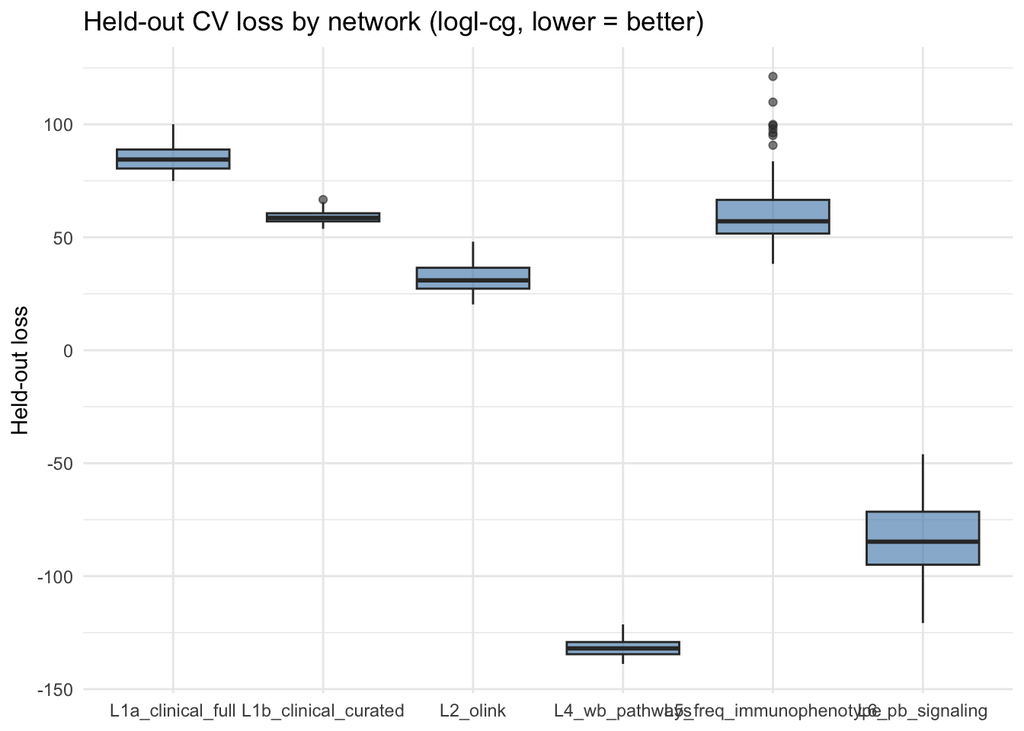

```r
loss_df <- bind_rows(lapply(names(models), function(nm) {
  m <- models[[nm]]
  if (is.null(m$cv_losses)) return(NULL)
  data.frame(network = nm, loss = m$cv_losses)
}))

if (nrow(loss_df) > 0) {
  ggplot(loss_df, aes(x = network, y = loss)) +
    geom_boxplot(fill = "steelblue", alpha = 0.6) +
    labs(title = "Held-out CV loss by network (logl-cg, lower = better)",
         x = NULL, y = "Held-out loss") +
    theme_minimal()
}
```

# 6. Validator handoff summary

```r
cat("=== HANDOFF SUMMARY ===\n\n")
```

```
## === HANDOFF SUMMARY ===
```

```r
cat("Model files in output/models/:\n")
```

```
## Model files in output/models/:
```

```r
for (f in list.files("output/models", pattern = "\\.rds$")) {
  cat(sprintf("  %s (%.1f KB)\n", f, file.size(file.path("output/models", f)) / 1024))
}
```

```
##   L1a_clinical_full_data_cv.rds (6.2 KB)
##   L1a_clinical_full_models_cv.rds (50.5 KB)
##   L1b_clinical_curated_data_cv.rds (5.0 KB)
##   L1b_clinical_curated_models_cv.rds (32.0 KB)
##   L2_olink_data_cv.rds (12.4 KB)
##   L2_olink_models_cv.rds (59.5 KB)
##   L4_wb_pathways_data_cv.rds (32.6 KB)
##   L4_wb_pathways_models_cv.rds (95.4 KB)
##   L5_freq_immunophenotype_data_cv.rds (55.3 KB)
##   L5_freq_immunophenotype_models_cv.rds (189.1 KB)
##   L6_pb_signaling_data_cv.rds (56.8 KB)
##   L6_pb_signaling_models_cv.rds (311.7 KB)
```

```r
cat("\nNode mappings in output/:\n")
```

```
##
## Node mappings in output/:
```

```r
for (f in list.files("output", pattern = "_node_mapping_cv\\.csv$")) {
  cat(sprintf("  %s\n", f))
}
```

```
##   L1a_clinical_full_node_mapping_cv.csv
##   L1b_clinical_curated_node_mapping_cv.csv
##   L2_olink_node_mapping_cv.csv
##   L4_wb_pathways_node_mapping_cv.csv
##   L5_freq_immunophenotype_node_mapping_cv.csv
##   L6_pb_signaling_node_mapping_cv.csv
```

```r
cat("\nTo load a model and run queries:\n")
```

```
##
## To load a model and run queries:
```

```r
cat('  models <- readRDS("output/models/L1b_clinical_curated_models_cv.rds")\n')
```

```
##   models <- readRDS("output/models/L1b_clinical_curated_models_cv.rds")
```

```r
cat('  fit <- models$fit_tabu\n')
```

```
##   fit <- models$fit_tabu
```

```r
cat('  cpquery(fit, event = (crp > 1.0), evidence = (age_group == "Older Adult"))\n')
```

```
##   cpquery(fit, event = (crp > 1.0), evidence = (age_group == "Older Adult"))
```

```r
cat("\nEdge confidence is now derived from cross-validation (models$cv_str),\n")
```

```
##
## Edge confidence is now derived from cross-validation (models$cv_str),
```

```r
cat("not bootstrap (models$boot_str no longer exists in CV-based model files).\n")
```

```
## not bootstrap (models$boot_str no longer exists in CV-based model files).
```

```r
cat("\nValidation data: ../data/processed/flu_response_validation.csv\n")
```

```
##
## Validation data: ../data/processed/flu_response_validation.csv
```

```r
cat("  Key: subject.subjectGuid (join to bn_ready_baseline.csv)\n")
```

```
##   Key: subject.subjectGuid (join to bn_ready_baseline.csv)
```

```r
cat("  Targets: val.igg_seroconvert, val.hai_peak (per antigen)\n")
```

```
##   Targets: val.igg_seroconvert, val.hai_peak (per antigen)
```